# 25 - Regresión - Ejercicios

# Regresión

En todos los casos grafique los datos para visualizarlos de la mejor manera que se le ocurra.

## 1. Regresión múltiple con mtcars

Objetivo: Determinar los factores que afectan el consumo de combustible de los automóviles.

Utiliza el dataset mtcars. La variable respuesta será mpg (millas por galón). Usa los siguientes predictores: - wt (peso del auto) - hp (caballos de fuerza) - cyl (número de cilindros) - gear (número de marchas) - Evalúa los supuestos del modelo: - Analiza los residuos para verificar homocedasticidad y normalidad. - Interpreta los coeficientes estimados. ¿Qué variables tienen un impacto significativo en el consumo?

```r
# install.packages("gridExtra")
library(ggplot2)
library(gridExtra)

p1 <- ggplot(mtcars, aes(x = wt, y = mpg)) +
  geom_point() +
  geom_smooth(method = "lm") +
  ggtitle("Cons.Fuel vs Peso")

p2 <- ggplot(mtcars, aes(x = hp, y = mpg)) +
  geom_point() +
  geom_smooth(method = "lm") +
  ggtitle("Cons.Fuel vs Cab.Fuerza")

p3 <- ggplot(mtcars, aes(x = factor(cyl), y = mpg)) +
  geom_boxplot() +
  ggtitle("Cons.Fuel por Núm.Cilindros")

p4 <- ggplot(mtcars, aes(x = factor(gear), y = mpg)) +
  geom_boxplot() +
  ggtitle("Cons.Fuel por Núm.Marchas")

grid.arrange(p1, p2, p3, p4, ncol = 2)
model_mtcars <- lm(mpg ~ wt + hp + cyl + gear, data = mtcars)
summary(model_mtcars)
```

```
Call:
lm(formula = mpg ~ wt + hp + cyl + gear, data = mtcars)

Residuals:
    Min      1Q  Median      3Q     Max
-3.4710 -1.7876 -0.6517  1.2362  5.9677

Coefficients:
            Estimate Std. Error t value Pr(>|t|)
(Intercept) 36.68953    5.97025   6.145 1.44e-06 ***
wt          -3.02263    0.85116  -3.551  0.00143 **
hp          -0.02170    0.01574  -1.379  0.17922
cyl         -0.81260    0.66320  -1.225  0.23106
gear         0.36259    1.00000   0.363  0.71974
---
Signif. codes:  0 ‘***’ 0.001 ‘**’ 0.01 ‘*’ 0.05 ‘.’ 0.1 ‘ ’ 1

Residual standard error: 2.551 on 27 degrees of freedom
Multiple R-squared:  0.8439,    Adjusted R-squared:  0.8208
F-statistic: 36.49 on 4 and 27 DF,  p-value: 1.599e-10
```

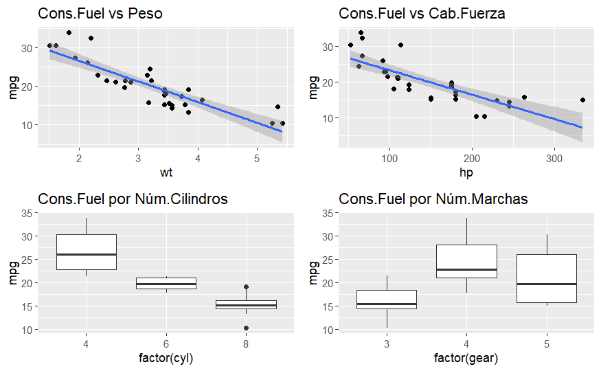

```r
# Test de homocedasticidad

par(mfrow = c(2, 2))
```

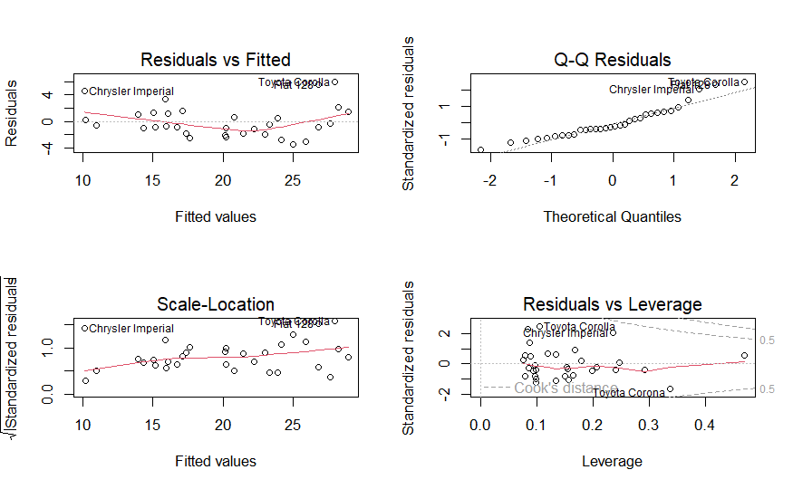

```r
plot(model_mtcars)
```

```r
# Test de normalidad

shapiro.test(residuals(model_mtcars))
```

```
    Shapiro-Wilk normality test

data:  residuals(model_mtcars)
W = 0.92128, p-value = 0.02253
```

```r
# Variable Significativa: El peso del automóvil (wt) es la única variable con un impacto significativo en el consumo de combustible (mpg).

# Variables No Significativas: Los caballos de fuerza (hp), el número de cilindros (cyl) y el número de marchas (gear) no muestran un impacto significativo en el consumo de combustible en este análisis.
```

## 2. Ejercicio: Predicción de precios con diamonds

Objetivo: Predecir el precio de los diamantes en función de sus características.

Trabaja con el dataset diamonds del paquete ggplot2. - ¿Cuál será la variable respuesta para cumplir con el objetivo? - Elija los predictores adecuados. - Evalúa la bondad de ajuste mediante el R² ajustado. - Compara dos modelos: uno con todos los predictores y otro más simple (elimina una o más variables).

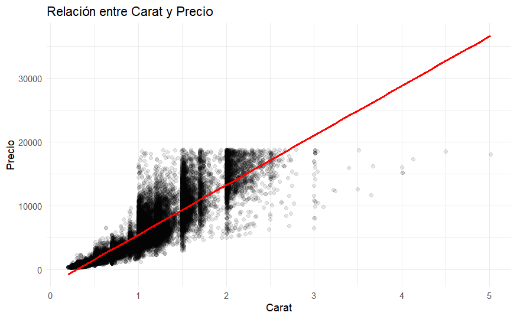

```r
# Paso 1: Cargo el paquete
library(ggplot2)
data(diamonds)

# Paso 2: Elijo la variable respuesta

# La variable respuesta en este análisis es 'price', que representa el precio de los diamantes.

# Carat vs Precio
ggplot(diamonds, aes(x = carat, y = price)) +
  geom_point(alpha = 0.1) +
  geom_smooth(method = "lm", col = "red") +
  theme_minimal() +
  labs(title = "Relación entre Carat y Precio", x = "Carat", y = "Precio")
```

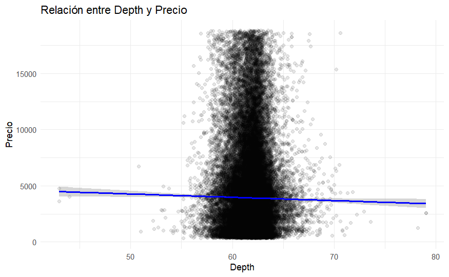

```r
# Depth vs Precio
ggplot(diamonds, aes(x = depth, y = price)) +
  geom_point(alpha = 0.1) +
  geom_smooth(method = "lm", col = "blue") +
  theme_minimal() +
  labs(title = "Relación entre Depth y Precio", x = "Depth", y = "Precio")
```

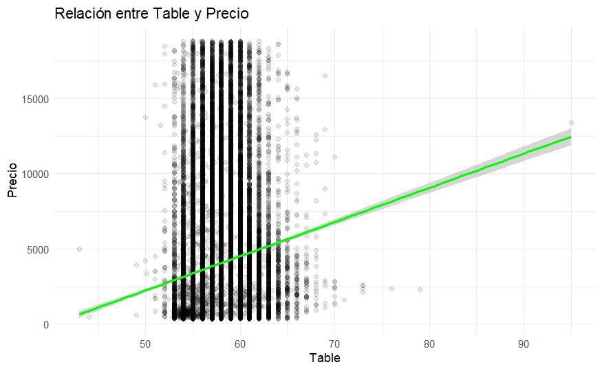

```r
# Table vs Precio
ggplot(diamonds, aes(x = table, y = price)) +
  geom_point(alpha = 0.1) +
  geom_smooth(method = "lm", col = "green") +
  theme_minimal() +
  labs(title = "Relación entre Table y Precio", x = "Table", y = "Precio")
```

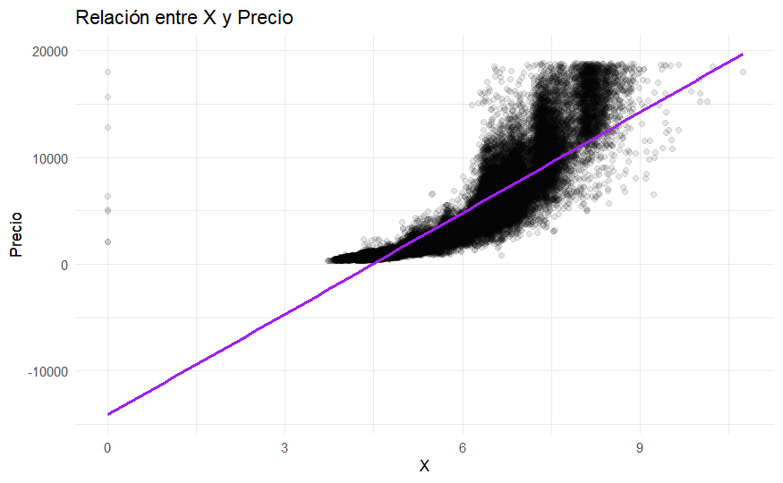

```r
# X vs Precio
ggplot(diamonds, aes(x = x, y = price)) +
  geom_point(alpha = 0.1) +
  geom_smooth(method = "lm", col = "purple") +
  theme_minimal() +
  labs(title = "Relación entre X y Precio", x = "X", y = "Precio")
```

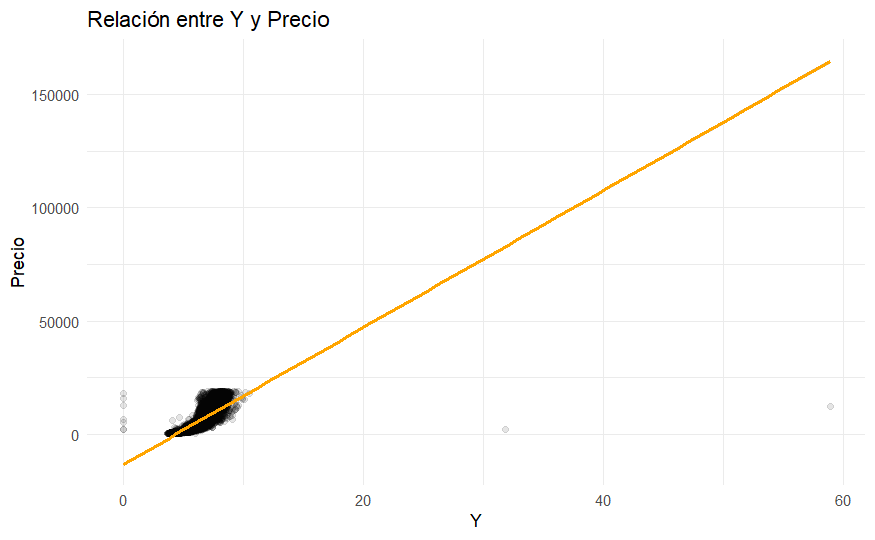

```r
# Y vs Precio
ggplot(diamonds, aes(x = y, y = price)) +
  geom_point(alpha = 0.1) +
  geom_smooth(method = "lm", col = "orange") +
  theme_minimal() +
  labs(title = "Relación entre Y y Precio", x = "Y", y = "Precio")
```

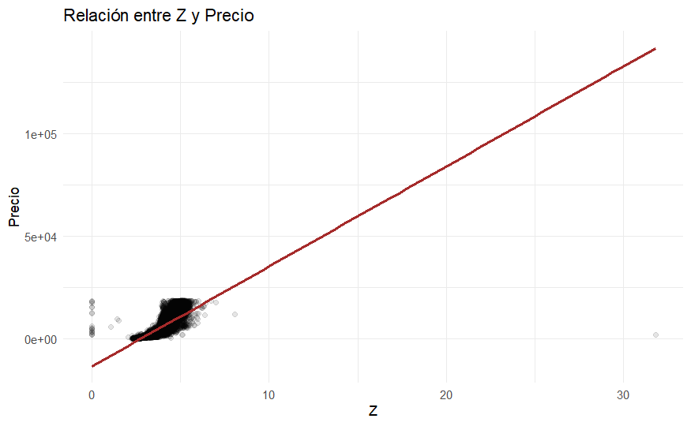

```r
# Z vs Precio
ggplot(diamonds, aes(x = z, y = price)) +
  geom_point(alpha = 0.1) +
  geom_smooth(method = "lm", col = "brown") +
  theme_minimal() +
  labs(title = "Relación entre Z y Precio", x = "Z", y = "Precio")
```

```r
# En base a los graficos elijo 'carat', 'cut', 'color' y 'clarity' como los predictores más adecuados ya que son las características más importantes que determinan el precio de los diamantes.

modelo_optimo <- lm(price ~ carat + cut + color + clarity, data = diamonds)


# Paso 4: Bondad de ajuste

bondad_optimo <- summary(modelo_optimo)$adj.r.squared

cat("R² ajustado del modelo con los predictores adecuados:", bondad_optimo, "\n")
```

```
R² ajustado del modelo con los predictores adecuados: 0.9159125
```

```r
# Paso 5: Comparo dos modelos

modelo_1 <- lm(price ~ carat + cut + color + clarity + depth + table + x + y + z, data = diamonds)

modelo_2 <- lm(price ~ carat + cut + color + clarity + depth, data = diamonds)

resumen_completo <- summary(modelo_1)
resumen_simplificado <- summary(modelo_2)


r2_completo <- resumen_completo$adj.r.squared
r2_simplificado <- resumen_simplificado$adj.r.squared


cat("R² ajustado del modelo completo:", r2_completo, "\n")
```

```
R² ajustado del modelo completo: 0.9197573
```

```r
cat("R² ajustado del modelo simplificado:", r2_simplificado, "\n")
```

```
R² ajustado del modelo simplificado: 0.9159167
```

## 3. Ejercicio: Regresión múltiple con interacciones usando iris

Objetivo: Estimar la longitud del pétalo en función de otras características y explorar interacciones.

- Utiliza el dataset iris. Elije una variable respuesta a explicar con las otras.
- ¿Cuáles son los posibles predictores?
- Introduce términos de interacción entre Species y las otras variables para evaluar si las relaciones difieren según la especie.
- Verifica si los coeficientes de las interacciones son significativos.

```r
# Paso 1: Cargo el dataset iris
library(ggplot2)
data(iris)

# La variable respuesta es "Petal.Length"

# Paso 2: Los predictores son "Sepal.Length", "Sepal.Width", "Petal.Width", y "Species"

modelo <- lm(Petal.Length ~ Sepal.Length * Species + Sepal.Width + Petal.Width, data = iris)

# Paso 3: Interaccion entre Species y las otras variables

modelo_interacciones <- lm(Petal.Length ~ Sepal.Length * Species + Sepal.Width * Species + Petal.Width * Species, data = iris)

# Paso 5: Verifico la significancia de los coeficientes

interacciones <- summary(modelo_interacciones)
valores_p <- interacciones$coefficients[,4]

coeficientes <- interacciones$coefficients
print(coeficientes)
```

```
                                  Estimate Std. Error    t value     Pr(>|t|)
(Intercept)                     0.86546731  0.4794319  1.8051935 7.322450e-02
Sepal.Length                    0.11605588  0.1419166  0.8177750 4.148954e-01
Speciesversicolor              -0.70040848  0.6240768 -1.1223113 2.636790e-01
Speciesvirginica               -0.40044024  0.6190080 -0.6469064 5.187671e-01
Sepal.Width                    -0.02865363  0.1303413 -0.2198354 8.263242e-01
Petal.Width                     0.46252684  0.3269145  1.4148250 1.593723e-01
Sepal.Length:Speciesversicolor  0.31980645  0.1625318  1.9676543 5.111290e-02
Sepal.Length:Speciesvirginica   0.62691587  0.1535140  4.0837698 7.471464e-05
Speciesversicolor:Sepal.Width  -0.07819591  0.1956839 -0.3996032 6.900666e-01
Speciesvirginica:Sepal.Width   -0.05360084  0.1850587 -0.2896423 7.725246e-01
Speciesversicolor:Petal.Width   0.89768102  0.4027411  2.2289284 2.743566e-02
Speciesvirginica:Petal.Width   -0.24688033  0.3568025 -0.6919243 4.901474e-01
```

```r
significativos <- coeficientes[valores_p < 0.05,]
print("Coeficientes significativos:")
```

```
[1] "Coeficientes significativos:"
```

```r
print(significativos)
```

```
                               Estimate Std. Error  t value     Pr(>|t|)
Sepal.Length:Speciesvirginica 0.6269159  0.1535140 4.083770 7.471464e-05
Speciesversicolor:Petal.Width 0.8976810  0.4027411 2.228928 2.743566e-02
```

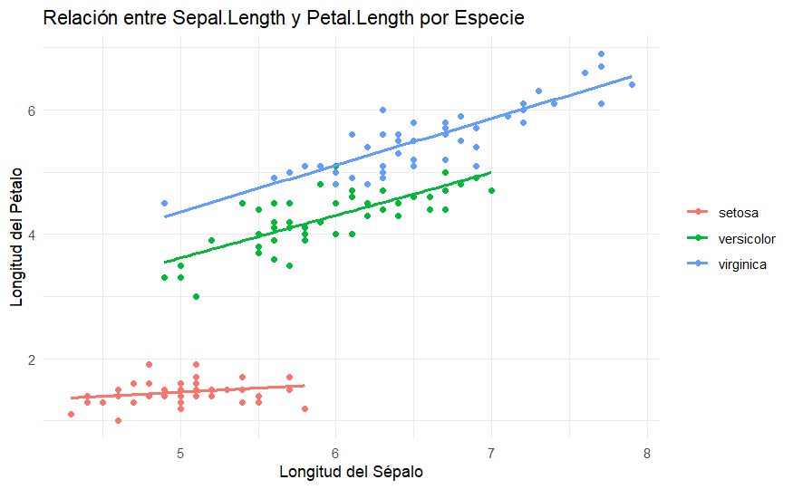

```r
# Grafico

ggplot(iris, aes(x = Sepal.Length, y = Petal.Length, color = Species)) +
  geom_point() +
  geom_smooth(method = "lm", aes(group = Species), se = FALSE) +
  labs(title = "Relación entre Sepal.Length y Petal.Length por Especie",
       x = "Longitud del Sépalo",
       y = "Longitud del Pétalo") +
  theme_minimal() +
  theme(legend.title = element_blank())
```

## 4. Modelado de datos ecológicos con airquality

Objetivo: Evaluar cómo diferentes factores ambientales afectan los niveles de ozono.

- ¿Cuál será la variable respuesta para cumplir con el objetivo?
- ¿Cuáles son los posibles predictores?
- Verifica si hay datos faltantes y decide cómo tratarlos (e.g., eliminación de casos o imputación).
- Ajusta un modelo de regresión y analiza qué factores afectan significativamente la concentración de ozono.
- Interpreta los resultados y sugiere acciones que podrían ayudar a reducir los niveles de ozono.

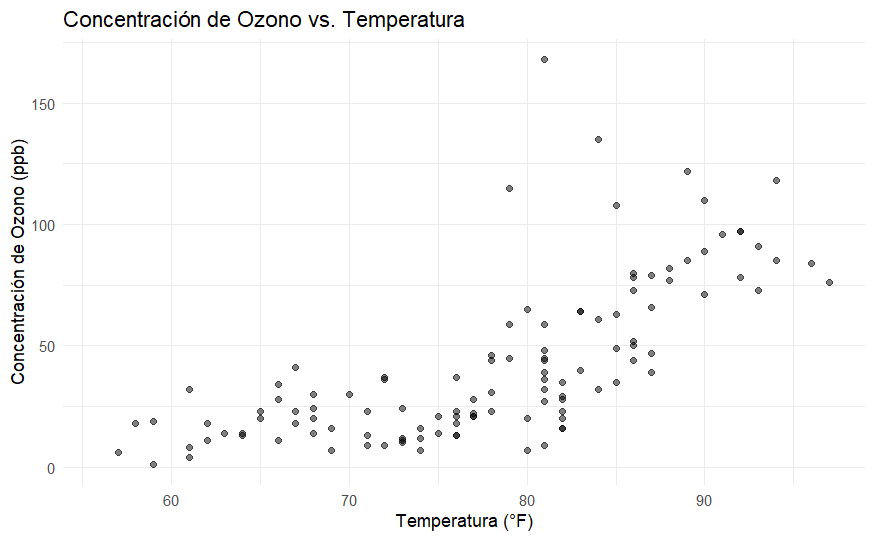

```r
data(airquality)


# Paso 1: Encontrar la variable respuesta

ggplot(airquality, aes(x = Temp, y = Ozone)) +
  geom_point(alpha = 0.5) +  # Puntos de datos
  labs(title = "Concentración de Ozono vs. Temperatura",
       x = "Temperatura (°F)",
       y = "Concentración de Ozono (ppb)") +
  theme_minimal()
```

```r
# La variable respuesta para evaluar cómo los diferentes factores ambientales afectan los niveles de ozono es "Ozone".

# Paso 2: Posibles predictores

correlations <- cor(airquality, use = "complete.obs")
print(correlations)
```

```
               Ozone     Solar.R        Wind       Temp        Month          Day
Ozone    1.000000000  0.34834169 -0.61249658  0.6985414  0.142885168 -0.005189769
Solar.R  0.348341693  1.00000000 -0.12718345  0.2940876 -0.074066683 -0.057753801
Wind    -0.612496576 -0.12718345  1.00000000 -0.4971897 -0.194495804  0.049871017
Temp     0.698541410  0.29408764 -0.49718972  1.0000000  0.403971709 -0.096545800
Month    0.142885168 -0.07406668 -0.19449580  0.4039717  1.000000000 -0.009001079
Day     -0.005189769 -0.05775380  0.04987102 -0.0965458 -0.009001079  1.000000000
```

```r
# En base a los resultados de las correlaciones, los posibles predictores son Solar.R, Wind y Temp

# Paso 3: Verificar y visualizar los datos faltantes

missing_data <- colSums(is.na(airquality))
print(missing_data)
```

```
  Ozone Solar.R    Wind    Temp   Month     Day
     37       7       0       0       0       0
```

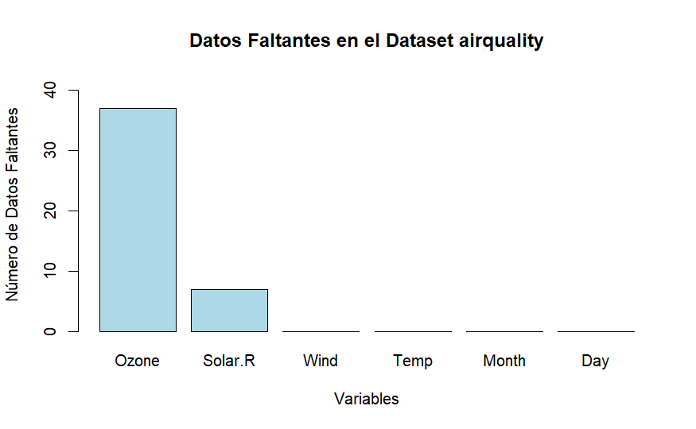

```r
barplot(missing_data,
        main = "Datos Faltantes en el Dataset airquality",
        xlab = "Variables",
        ylab = "Número de Datos Faltantes",
        col = "lightblue",
        ylim = c(0, max(missing_data) + 5))
```

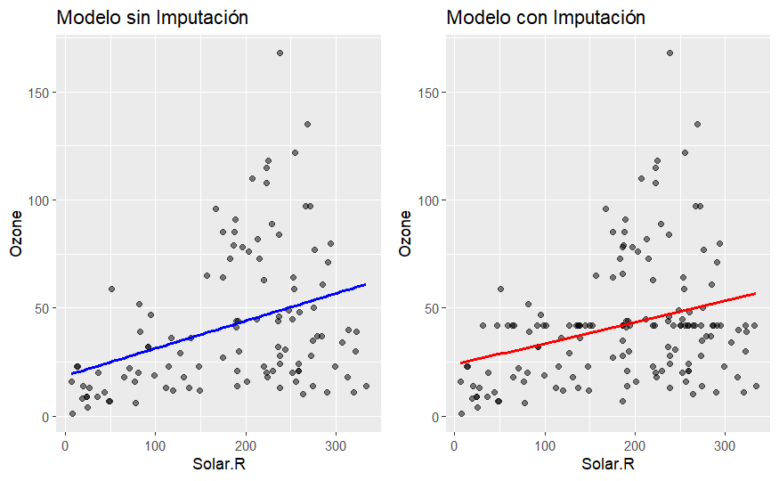

```r
# La cantidad de datos faltantes es relativamente baja pero decido hacer un analisis de sensibilidad para ver como afecta a los resultados con y sin imputación

modelo_sin_imputacion <- lm(Ozone ~ Solar.R + Wind + Temp, data = na.omit(airquality))

modelo_imputado <- airquality
modelo_imputado$Ozone[is.na(modelo_imputado$Ozone)] <- mean(modelo_imputado$Ozone, na.rm = TRUE)
modelo_imputado$Solar.R[is.na(modelo_imputado$Solar.R)] <- mean(modelo_imputado$Solar.R, na.rm = TRUE)

# Graficos con y sin imputacion para visualizar las diferencias

grafico1 <- ggplot(modelo_sin_imputacion, aes(x = Solar.R, y = Ozone)) +
  geom_point(alpha = 0.5) +
  geom_smooth(method = "lm", color = "blue", se = FALSE) +
  labs(title = "Modelo sin Imputación", x = "Solar.R", y = "Ozone")

grafico2 <- ggplot(modelo_imputado, aes(x = Solar.R, y = Ozone)) +
  geom_point(alpha = 0.5) +
  geom_smooth(method = "lm", color = "red", se = FALSE) +
  labs(title = "Modelo con Imputación", x = "Solar.R", y = "Ozone")

grid.arrange(grafico1, grafico2, nrow = 1)
```

```r
# Paso 4: Modelo de regresión

modelo_regresion <- lm(Ozone ~ Solar.R + Wind + Temp, data = modelo_imputado)

regresion <- summary(modelo_regresion)
cat("Datos del modelo de regresión: /n")
```

```
Datos del modelo de regresión: /n
```

```r
print(regresion)
```

```
Call:
lm(formula = Ozone ~ Solar.R + Wind + Temp, data = modelo_imputado)

Residuals:
    Min      1Q  Median      3Q     Max
-38.618 -14.491  -5.054  12.270 101.176

Coefficients:
             Estimate Std. Error t value Pr(>|t|)
(Intercept) -38.22315   18.88338  -2.024  0.04474 *
Solar.R       0.05775    0.02003   2.883  0.00452 **
Wind         -2.71725    0.54280  -5.006 1.55e-06 ***
Temp          1.24126    0.20906   5.937 1.96e-08 ***
---
Signif. codes:  0 ‘***’ 0.001 ‘**’ 0.01 ‘*’ 0.05 ‘.’ 0.1 ‘ ’ 1

Residual standard error: 20.9 on 149 degrees of freedom
Multiple R-squared:   0.48, Adjusted R-squared:  0.4696
F-statistic: 45.85 on 3 and 149 DF,  p-value: < 2.2e-16
```

```r
# Segun el modelo de regresión, los factores que afectan significativamente la concentracion de ozono son: la radiación solar (Solar.R), el viento (Wind) y la temperatura (Temp)
```